# Game of Thrones — Season 1 Viewership Report

## About the Show

*Game of Thrones* is an American fantasy drama television series created by David Benioff and D. B. Weiss for HBO. Based on George R. R. Martin’s *A Song of Ice and Fire* novels, the show premiered on **April 17, 2011** and ran for eight seasons, concluding on May 19, 2019 with 73 episodes total.

Set across the fictional continents of Westeros and Essos, the series follows political power struggles over the Iron Throne, the exiled Targaryen heir plotting her return, and the Night’s Watch defending against supernatural threats from the North. Critics praised its acting, complex characters, and production values. It received **59 Primetime Emmy Awards** — the most ever for a drama series.

[figure not shown]

## Season 1 Statistics

| Metric | Viewers (millions) |
| --- | --- |
| Minimum (M) | 2.200000 |
| Maximum (M) | 3.040000 |
| Average (M) | 2.520000 |
| Median (M) | 2.450000 |

## Viewership Over Time

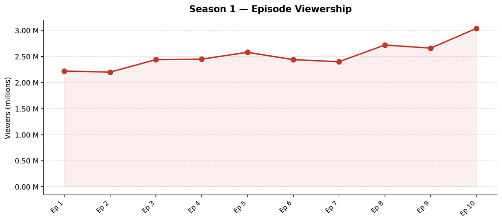

## Episode-to-Episode Change in Viewership

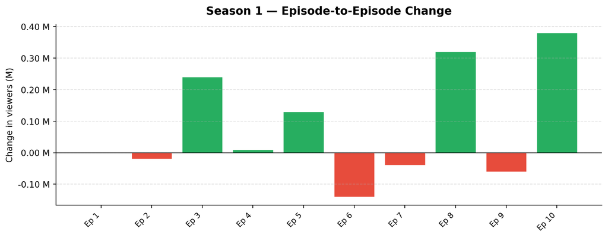

## Observations

Season 1 opened to **2.22 million viewers** and showed modest fluctuation through the middle episodes. Viewership dipped slightly to a season low of **2.20 M** in Episode 2 (*The Kingsroad*), then held relatively steady in the 2.40–2.58 M range through Episodes 3–7.